# Econometría

v.2026.11.13

PDF

## ¿Es suficiente una relación lineal?

## Volvamos a una pregunta conocida

¿Recuerdas cómo era la asociación entre el ingreso per cápita y la esperanza de vida?

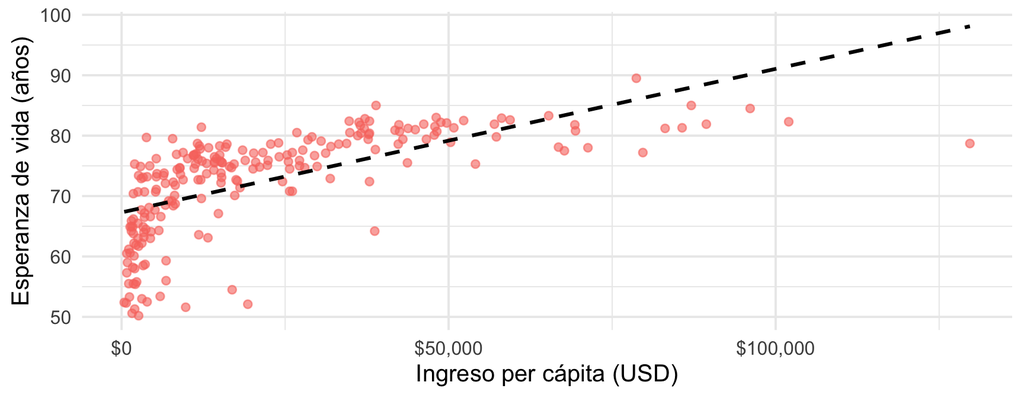

> La asociación entre ambas variables fue representada mediante una línea recta. ¿Que significa esto?

## ¿Qué suponía nuestra recta?

Recordemos el modelo de regresión lineal simple:

\[ y_i=\beta_1+\beta_2x_i+u_i \] Cuando suponemos que \(E(u_i)=0\), tenemos:

\[ \begin{align} m(x)&=E(y_i)\\ &=\beta_1+\beta_2x \ \Rightarrow \ \frac{dm(x)}{dx}=\beta_2 \end{align} \]

> La pendiente es constante: un mismo incremento del ingreso se asocia con el mismo cambio en la esperanza de vida, independientemente del ingreso inicial.

## ¿Y si la pendiente cambia?

- ¿Es razonable suponer que un aumento de $1,000 en el ingreso per cápita se asocia con el mismo cambio en la esperanza de vida de países pobres y ricos?
- La relación podría ser más pronunciada entre países de ingresos bajos y menos pronunciada entre países de ingresos elevados.

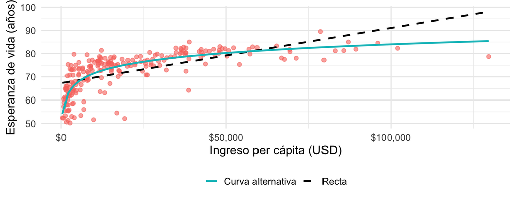

> ¿Cómo podemos representar y estimar relaciones económicas más flexibles?

## Linealidad en los parámetros

## Una relación no lineal también puede estimarse por MCO

Consideremos:

\[ y_i=\beta_1+\beta_2x_{2i}^2+\beta_3\sqrt{x_{3i}}+\beta_4\ln(x_{4i})+u_i. \]

Aunque la función es no lineal en las variables, los parámetros aparecen linealmente.

> La regresión lineal requiere **linealidad en los parámetros**, no necesariamente en las variables.

## Redefiniendo los regresores

Definamos:

\[ z_{2i}=x_{2i}^2,\qquad z_{3i}=\sqrt{x_{3i}},\qquad z_{4i}=\ln(x_{4i}). \]

Entonces:

\[ y_i=\beta_1+\beta_2z_{2i}+\beta_3z_{3i}+\beta_4z_{4i}+u_i. \]

La estimación por MCO sigue siendo posible, siempre que las transformaciones estén definidas y se satisfagan los supuestos pertinentes.

> Transformar los regresores no implica abandonar el modelo lineal.

## ¿Y si los parámetros aparecen de forma no lineal?

Consideremos:

\[ y_i=\beta_1x_{2i}^{\beta_2}+u_i. \]

El exponente \(\beta_2\) es un parámetro desconocido. No podemos redefinir \(x_{2i}^{\beta_2}\) como un regresor conocido.

> Este modelo, con error aditivo en niveles, no se estima directamente por MCO lineal.*

## ¿Podemos transformar también la variable dependiente?

Consideremos, en cambio, un modelo con un *error multiplicativo*:

\[ y_i=A x_{2i}^{\beta_2}e^{u_i},\qquad A>0,\ x_{2i}>0. \]

Aplicando logaritmos, para \(y_i>0\):

\[ \ln(y_i)=\beta_1^*+\beta_2\ln(x_{2i})+u_i. \]

> Transformar el modelo también exige considerar cómo se especifica el término de error.

## Modelos logarítmicos

## ¿Por qué utilizar logaritmos?

En algunas relaciones económicas estamos interesados en estudiar *cambios absolutos*; en otras, *cambios proporcionales*. Por ejemplo:

- ¿Cómo cambia la esperanza de vida de los países cuando cambia el ingreso per cápita?
- ¿En qué porcentaje cambia la esperanza de vida cuando cambia el ingreso per cápita en 1 %?
- ¿En cuántos años cambia la esperanza de vida cuando cambia el ingreso per cápita en 1 %?

Como veremos, para responder a estas preguntas hacemos una transformación logarítmica. Es imporante destacar que *la transformación elegida debe responder a la pregunta económica y ser compatible con los datos*.

## Modelo log-log: elasticidad constante

Consideremos:

\[ \ln(y_i)=\beta_1+\beta_2\ln(x_{2i})+u_i, \qquad y_i>0,\ x_{2i}>0. \]

Sea \(g(x_2)\) la parte sistemática del modelo en niveles: \(g(x_2)=\exp(\beta_1)x_2^{\beta_2}\). Entonces:

\[ \varepsilon_{g,x_2} =\frac{dg}{dx_2}\frac{x_2}{g(x_2)} =\frac{d\ln g}{d\ln x_2}=\beta_2. \]

Por tanto, \(\beta_2\) es la **elasticidad** de esa función respecto de \(x_2\).

> ¡Un aumento pequeño del 1% en \(x_2\) corresponde aproximadamente a un cambio de \(\beta_2\)% en \(g(x_2)\)!

## Ejemplo: función de producción Cobb-Douglas

Considera, por ejemplo, la estimación de una función de producción Cobb-Douglas para 51 observaciones de los Estados Unidos:

\[ \widehat{\ln(output)} =3.8876+0.4683\ln(labor)+0.5213\ln(capital). \]

- Elasticidad respecto del trabajo: \(0.4683\), manteniendo constante el capital.
- Elasticidad respecto del capital: \(0.5213\), manteniendo constante el trabajo.
- Además, nota que \(b_2+b_3=0.9896\).

> ¿Que la suma de los coeficientes sea cercana a uno basta para afirmar que existen rendimientos constantes a escala?

## Modelo log-lin: semielasticidad constante

Consideremos:

\[ \ln(y_i)=\beta_1+\beta_2x_{2i}+u_i, \qquad y_i>0. \]

Sea \(g(x_2)\) la parte sistemática del modelo en niveles. Aquí \(g(x_2)=\exp(\beta_1+\beta_2x_2)\). En este caso:

\[ \frac{1}{g(x_2)}\frac{dg}{dx_2} =\beta_2, \qquad \varepsilon_{g,x_2}=\beta_2x_2. \]

Un incremento unitario de \(x_2\) se asocia con una variación *aproximada* de \(100\beta_2\)% en \(g\). La variación porcentual *exacta* implícita en la función exponencial del componente sistemático es:

\[ 100(e^{\beta_2}-1)\%. \]

## Ejemplo: crecimiento del PIB

Consideremos, por ejemplo, la estimación del PIB real de los Estados Unidos. Si consideramos los 48 periodos observados:

\[ \widehat{\ln(PIB)}=7.87566+0.0314896\,t. \]

El crecimiento porcentual aproximado de la función exponencial entre periodos consecutivos es:

\[ 100b_2\approx3.15\%, \]

mientras que el cambio exacto es:

\[ 100(e^{0.0314896}-1)\approx3.20\%. \]

*La especificación impone una tasa de crecimiento proporcional constante por periodo.*

## Modelo lin-log: cambios absolutos y proporcionales

Consideremos:

\[ y_i=\beta_1+\beta_2\ln(x_{2i})+u_i, \qquad x_{2i}>0. \]

Para \(m(x_2)=\beta_1+\beta_2\ln(x_2)\):

\[ \frac{dm}{dx_2}=\frac{\beta_2}{x_2},\qquad \frac{dm}{d\ln(x_2)}=\beta_2. \]

Un incremento pequeño del 1% en \(x_2\) se asocia aproximadamente con un cambio de \(\beta_2/100\) unidades de \(y\).

## Ejemplo: participación del gasto alimentario

Considera la proporción del gasto total destinada a alimentos en función del logaritmo del gasto total:

\[ \widehat{sfdho}=0.930387-0.0777372\ln(expend). \]

Un aumento del 1% en el gasto total del hogar se asocia con una disminución aproximada de la proporción destinada a alimentos:

\[ \Delta\widehat{sfdho}\approx-0.0777372(0.01)=-0.0007774. \]

Como \(sfdho\) es una proporción, esto equivale a una reducción de aproximadamente **0.078 puntos porcentuales** en la participación del gasto alimentario.

> ¿Significa esto que los hogares con mayor gasto destinan menos dinero a alimentos?

## Modelo recíproco

## ¿Puede una relación aproximarse a un límite?

Consideremos la relación entre ingreso per cápita y esperanza de vida. ¿Esperamos que un aumento del ingreso produzca siempre la misma mejora en la esperanza de vida?

Como hemos dicho: es posible que las mejoras sean mayores cuando el ingreso inicial es bajo y cada vez menores cuando aumenta.

> ¿Qué especificación nos permitiría representar una relación que se aproxima a un límite?

## Modelo recíproco

El **modelo recíproco** se escribe:

\[ y_i=\beta_1+\beta_2\frac{1}{x_i}+u_i,\qquad x_i>0. \]

Este modelo puede estimarse por MCO si definimos a \(z_i=1/x_i\). Nota que, para \(m(x)=\beta_1+\beta_2/x\):

\[ \frac{dm(x)}{dx}=-\frac{\beta_2}{x^2}, \qquad \lim_{x\to\infty}m(x)=\beta_1. \]

Si \(\beta_2<0\), la función es creciente y su pendiente disminuye cuando aumenta \(x\). Además, *¡la parte sistemática se aproxima a \(\beta_1\)!*

## Ejemplo: participación del gasto alimentario

Considera nuevamente la estimación del gasto en alimentos en función del gasto total. Ahora tenemos:

\[ \widehat{sfdho}=0.077263+\frac{1331.34}{expend}. \]

Para \(expend>0\), el efecto marginal es negativo:

\[ \frac{d\widehat{sfdho}}{d(expend)} =-\frac{1331.34}{expend^2}. \]

Y la función estimada se aproxima a \(0.077263\), es decir, cerca de **7.73% del gasto total**.

*Es una implicación de la especificación, no un límite económico demostrado.*

## Esperanza de vida e ingreso

Ejercicio

Considera el modelo de ingreso per cápita como variable explicativa de la esperanza de vida. Antes encontramos:

\[ \widehat{\text{Esperanza de vida}}_i = 67.35 + 0.00024\text{Ingreso per cápita}_i \]

Pero, si consideramos el modelo recíproco:

\[ \widehat{\text{Esperanza de vida}}_i=76.0391-\frac{19263.07}{\text{Ingreso per cápita}_i}. \]

Grafica ambas líneas junto con los datos. ¿Cuál parece ser un mejor modelo? Compara e interpreta.

## Modelos polinómicos

## ¿Puede cambiar el efecto con el nivel de la variable?

En el modelo log-lin del PIB:

\[ \ln(PIB_i)=\beta_1+\beta_2t_i+u_i, \]

la pendiente de la parte sistemática en logaritmos es constante:

\[ \frac{dm(t)}{dt}=\beta_2. \]

*¿Qué ocurre si la tasa de crecimiento se acelera o desacelera con el tiempo?*

## El modelo cuadrático

El **modelo cuadrático** se especifica como:

\[ y_i=\beta_1+\beta_2x_{2i}+\beta_3x_{2i}^2+u_i. \]

Claramente, el modelo es lineal en los parámetros y puede estimarse mediante MCO. Pero nota que el efecto marginal de \(x_{2i}\) es ahora:

\[ \frac{dm(x_2)}{dx_2}=\beta_2+2\beta_3x_2. \]

Entonces, \(\beta_2\) representa el efecto marginal cuando \(x_2=0\); \(\beta_3\) determina cómo cambia ese efecto. Esto es: *la pendiente ya no es constante.*

## Curvatura y puntos de máximo o mínimo

En el modelo cuadrático, la segunda derivada con respecto de \(x_{2i}\) es:

\[ \frac{d^2m(x_2)}{dx_2^2}=2\beta_3. \]

Entonces, el efecto marginal es una:

- función cóncava si \(\beta_3<0\).
- función convexa si \(\beta_3>0\).

El efecto marginal es cero cuando:

\[ x_2^*=-\frac{\beta_2}{2\beta_3},\qquad \beta_3\neq0. \]

Este es el punto de inflexión. Nota que *un punto de inflexión fuera del intervalo observado no significa que hayamos encontrado un máximo o mínimo en la muestra.*

## Ejemplo: crecimiento del PIB

Consideremos un modelo cuadrático para el crecimiento del PIB en los EE.UU.

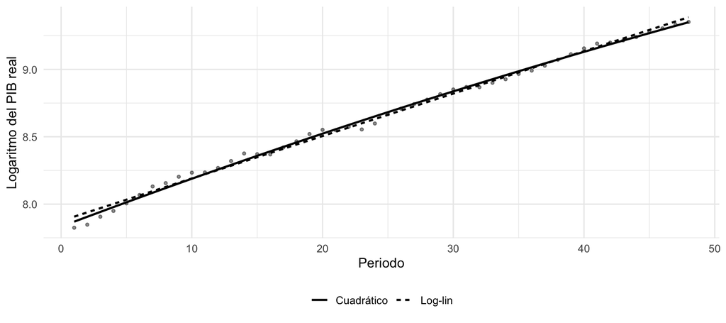

\[ \widehat{\ln(PIB)} =7.83348+0.0365515t-0.000103304t^2 \]

- La pendiente de esta función en logaritmos es:

\[ \frac{d\widehat{\ln(PIB)}}{dt} =0.0365515-0.000206608t. \]

- La tasa instantánea implícita disminuye de aproximadamente \(3.63\%\) (\(t=1\)) a \(2.66\%\) (\(t=48\)).
- El máximo matemático está cerca de \(t=176.9\), **fuera de la muestra**.

## Polinomios de grado superior

También podemos plantear modelos con polinomios mayores a dos. Por ejemplo, un **polinomio cúbico**:

\[ y_i=\beta_1+\beta_2x_{2i}+\beta_3x_{2i}^2 +\beta_4x_{2i}^3+u_i. \]

En esta caso, el efecto marginal de \(x_{2i}\) es:

\[ \frac{dm(x_2)}{dx_2} =\beta_2+2\beta_3x_2+3\beta_4x_2^2. \]

Estos modelos siguen siendo lineales en los parámetros y se pueden estimar por MCO.

## ¿Cuándo conviene introducir un polinomio?

Un término cuadrático permite estudiar si la pendiente cambia con el nivel del regresor. Por supuesto, lo primero que queremos probar es:

\[ H_0:\beta_3=0. \]

Pero debemos valorar también:

- ¿Existe una razón económica para admitir curvatura?
- ¿Cómo se comporta la función dentro de la muestra?
- ¿Qué tan precisas son las estimaciones? ¿Existe multicolinealidad importante?

> Cuidado: Incorporar potencias indiscriminadamente no equivale a mejorar la especificación.

## Modelos con interacciones

## ¿Puede el efecto de una variable depender de otra?

Recordemos la relación entre precio, publicidad y ventas que estudiamos antes. En regresión lineal múltiple suponíamos que el efecto parcial del precio es constante al mantener fija la publicidad.

Pero: *¿Podría la publicidad modificar la relación entre precio y ventas?*

## El modelo con interacciones

Podemos incorporar una **interacción** entre dos regresores. Por ejemplo:

\[ y_i=\beta_1+\beta_2x_{2i}+\beta_3x_{3i} +\beta_4x_{2i}x_{3i}+u_i. \]

Si definimos como \(z_i=x_{2i}x_{3i}\), el modelo sigue siendo lineal en los parámetros y puede estimarse por MCO.

> La interacción permite que el efecto parcial de un regresor dependa del nivel de otro.

## Interpretación de los efectos parciales

Nota que ahora:

\[ \frac{\partial m}{\partial x_2}=\beta_2+\beta_4x_3, \qquad \frac{\partial m}{\partial x_3}=\beta_3+\beta_4x_2. \]

Y la derivada cruzada:

\[ \frac{\partial^2m}{\partial x_2\partial x_3}=\beta_4. \]

Entonces, *los coeficientes \(\beta_2\) y \(\beta_3\) corresponden a efectos parciales cuando el otro regresor vale cero.*

## Ejemplo: precio, publicidad y ventas

En el ejemplo de Andy tenemos:

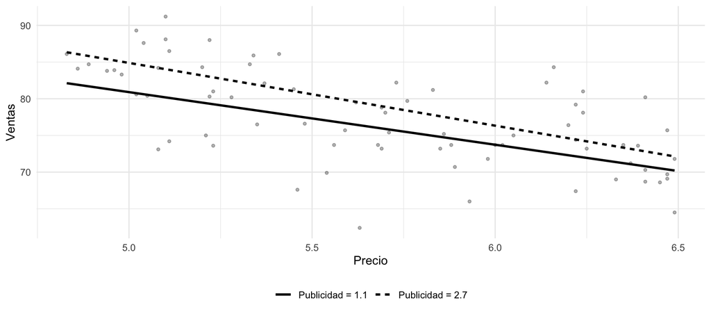

\[ \widehat{ventas}=109.2694-6.2205\,precio+6.8067\,publicidad -0.8638\,(precio\times publicidad). \]

Para niveles de publicidad de \(1.1\) y \(2.7\), el efecto parcial estimado del precio es \(-7.17\) y \(-8.55\), respectivamente. Entonces, *las pendientes pueden cambiar, pero debemos evaluar la precisión de esa diferencia.*

## Inferencia sobre los efectos parciales

En el ejemplo de Andy, podemos evaluar si la relación entre precio y ventas depende de la publicidad. Para esto establecemos:

\[ H_0:\beta_4=0. \]

De la regresión obtenemos que \(b_4=-0.8638\), con valor \(p=0.495\). (¿Qué significa esto?)

También podemos evaluar el efecto parcial del precio cuando \(publicidad=a\). Para esto establecemos:

\[ H_0:\beta_2+a\beta_4=0. \]

## ¿Cuándo conviene introducir una interacción?

Antes de incorporar una interacción debemos preguntarnos:

- ¿Por qué esperamos que una variable modifique la relación entre otras dos?
- ¿Cómo cambia la interpretación de los coeficientes?
- ¿Nuestros datos permiten estimar y evaluar los efectos parciales pertinentes?

En general, conservaremos también los dos términos principales, a menos que exista una justificación para restringirlos.

> Una interacción debe responder a una hipótesis económica, no al deseo de complicar el modelo.

## ¿Cómo elegir una forma funcional?

## ¿Qué debemos considerar?

La especificación debe responder a la pregunta que queremos estudiar:

- ¿Qué relación económica pretendemos representar?
- ¿Qué restricciones impone la forma funcional sobre los efectos marginales y las elasticidades?
- ¿Qué evidencia aportan los datos para evaluar la relación?

*No existe una especificación universalmente adecuada para todas las relaciones económicas.*

## Una relación económica, dos especificaciones

Para la participación del gasto alimentario, con \(expend>0\):

\[ \begin{aligned} \text{Lin-log:}\quad \widehat{sfdho}&=0.930387-0.0777372\ln(expend),\\[0.3em] \text{Recíproco:}\quad \widehat{sfdho}&=0.077263+\frac{1331.34}{expend}. \end{aligned} \]

Ambas representan relaciones decrecientes con pendientes de magnitud cada vez menor. Sin embargo, *solo el recíproco impone una asíntota horizontal finita al crecer el gasto.*

## ¿Qué nos dice la evidencia?

Ambos modelos emplean la misma variable dependiente y 869 observaciones.

| Modelo | R² | R² ajustada |
| --- | --- | --- |
| Lin-log | 0.3509 | 0.3501 |
| Recíproco | 0.3332 | 0.3325 |

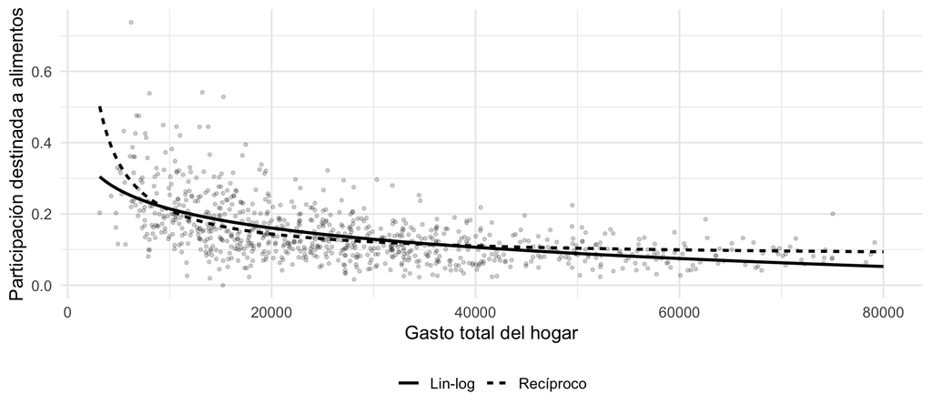

*Un ajuste ligeramente mayor no garantiza una especificación económicamente adecuada.*

## Resumen

## ¿Qué hemos aprendido?

- Los modelos lineales en los parámetros permiten representar relaciones económicas más flexibles sin abandonar necesariamente MCO.
- La forma funcional determina cómo se interpretan los coeficientes, efectos marginales y elasticidades.
- Las transformaciones, los polinomios y las interacciones requieren una justificación económica y empírica.

> Una buena especificación responde a la pregunta y reconoce lo que los datos permiten concluir.

## ¿Qué sigue?

Hasta ahora hemos utilizado principalmente regresores cuantitativos. ¿Cómo incorporar características cualitativas como el tipo de empresa, el grupo de trabajadores o la región? Las **variables dummy** nos permitirán incorporar estas características, estudiar diferencias entre grupos y ampliar nuevamente las posibilidades de especificación.

> Una nueva herramienta para construir modelos que representen mejor las relaciones económicas.